# Logistic Regression

## Outliers

- Use the `car` library and the `influencePlot()` to create a picture of the outliers.
  - Are there major outliers for this data?

```r
library(car)
```

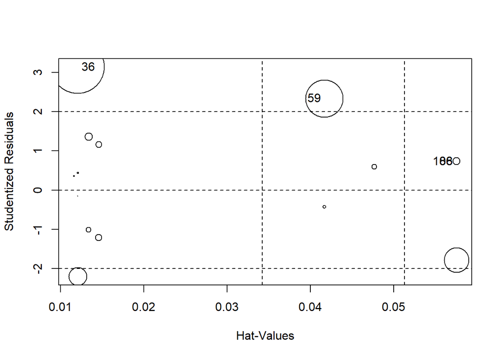

```
##      StudRes        Hat       CookD
## 36  3.136508 0.01204819 0.168699187
## 59  2.334111 0.04166667 0.083175803
## 88  0.732927 0.05752692 0.003198719
## 106 0.732927 0.05752692 0.003198719
```

```r
influencePlot(model2)#There are 2 major outliers at the top beyond 2(the
```

```r
#dashed line.)
```

## Assumptions

- Explore the `vif` values of the original model (not the interaction model) and determine if you meet the assumption of additivity (meaning no multicollinearity).

```r
rms::vif(model)#There is no multicollinearity here since there are no
```

```
##         Reg=SPOK Permitter=Inanim  Permitter=Undef        Imper=Yes
##         1.080051         1.069528         1.027143         1.051163
```

```r
#values above 5
```

No Python in this section! You will use the functions from this week in a few assignments coming up!